# Population Densities - Comparing Across (Selected) Countries

## Notebook Summary

This notebook looks at population density metrics for a set of selected countries. The basic flow is reading in the data, some data manipulation, then reviewing various plots.

Current countries in the data source: - Australia - United States of America

### 1. Initialize and Read in the Data

Data is sourced from the relevant national statistical agencies and gathered using scripts in the `data-raw` directory with results stored as `csv` files in the `inst/extdata` directory and as `rda` files in the `data` directory.

```r
# Load library for successful knit
library(geo.popn.density)

# Set up variables we will reuse in the notebook
ccode = "Country_Code"
msa_name = "MSA_Name"
ppn_est = "Popn_Est"
area = "Area_km2"
density = "Density"
ppn_pct = "Perc_Popn"
cum_pct = "Cum_Popn_Perc"
method = "method"

# Get the data
all_data <- GetAllData()
```

### 2. Data Review

#### 2.1 Density Calculations by Country

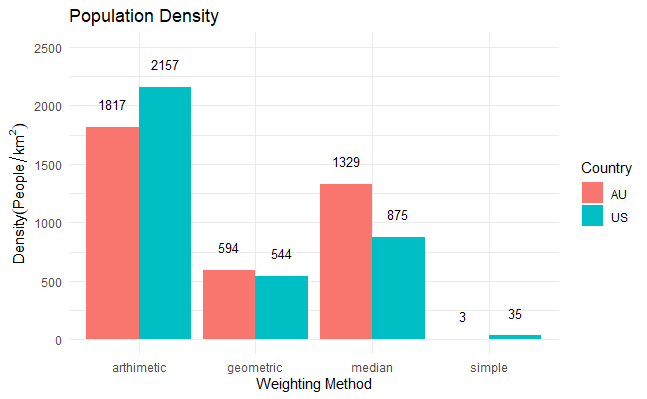

```r
densities <- CalcDensities(all_data, ccode = ccode, ppn_est = ppn_est,
                               area = area, density = density, group_by = ccode)
PlotDensities(densities, density = density, ccode = ccode)
```

#### 2.2 The Median Statistical Area by Density

```r
# Sorting the data by descending data and calculating the cumulative percentage population to find the median
all_by_density <- CalcCumPercent(all_data, cum_pct = cum_pct, metric = ppn_est, sort_by = density, group_by = ccode)
mdn_sa <- FindMedian(all_by_density, cum_pct = cum_pct)
dplyr::select(mdn_sa, Country_Code, State_Abbr, MSA_Name, SA_Code, Popn_Est, Area_km2, Density, Cum_Popn_Perc)
```

| Country_Code | State_Abbr | MSA_Name | SA_Code | Popn_Est | Area_km2 | Density | Cum_Popn_Perc |
| --- | --- | --- | --- | --- | --- | --- | --- |
| AU | QLD | Brisbane | 301021007 | 15813 | 11.900000 | 1328.8235 | 50.03095 |
| US | CO | Denver-Aurora-Lakewood, CO | 8059009856 | 2983 | 3.409431 | 874.9261 | 50.00004 |

#### 2.3 Statistical Areas by Descending Density

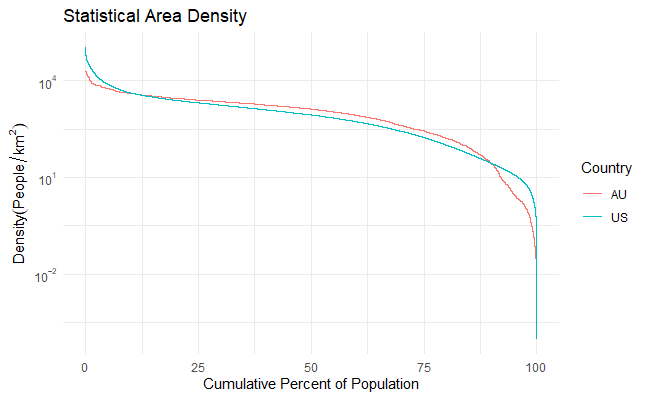

```r
PlotAllDataByDensity(all_by_density, density = density, ccode = ccode, cum_pct = cum_pct)
```

#### 2.4 The Median Metropolitan Area by Population

```r
# Group the data into its metropolitan statistical areas
msas <- GroupData(all_data, ppn_est = ppn_est, area = area, ppn_pct = ppn_pct,
                  density = density,
                  group_by = c(ccode, "MSA_Code", msa_name, "Metro_Micro"))

# Sort by population descending
msas_by_popn <- SortMSAsbyPopn(msas, cum_pct = cum_pct, ppn_est = ppn_est, ppn_pct = ppn_pct, msa_name = msa_name, group_by = ccode)
mdn_msa_popn <- FindMedian(msas_by_popn, cum_pct = cum_pct)
dplyr::select(mdn_msa_popn, Country_Code, MSA_Name, Popn_Est, Area_km2, Density, Cum_Popn_Perc)
```

| Country_Code | MSA_Name | Popn_Est | Area_km2 | Density | Cum_Popn_Perc |
| --- | --- | --- | --- | --- | --- |
| AU | Perth | 2099533 | 3531.70 | 594.4823 | 56.17716 |
| US | Cincinnati, OH-KY-IN | 2256884 | 11994.15 | 188.1653 | 50.45231 |

#### 2.5 Metroplitan Areas by Descending Population

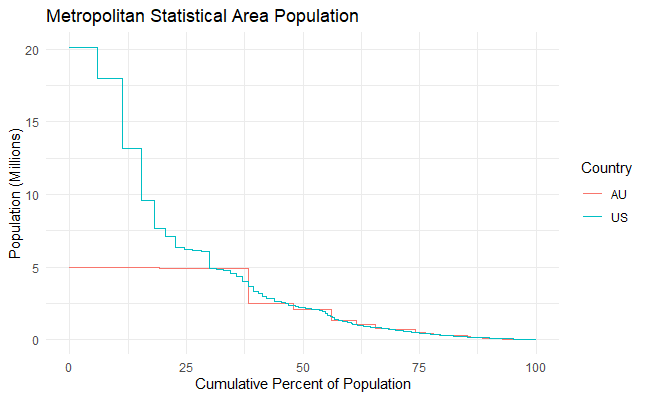

```r
PlotMSAsByPopn(msas_by_popn, ppn_est = ppn_est, ccode = ccode, cum_pct = cum_pct)
```

#### 2.6 The Median Metropolitan Area by Simple Density

```r
msas_by_density <- SortMSAsbyDensity(msas, cum_pct = cum_pct, density = density, ppn_pct = ppn_pct, group_by = ccode)
mdn_msa_density <- FindMedian(msas_by_density, cum_pct = cum_pct)
dplyr::select(mdn_msa_density, Country_Code, MSA_Name, Popn_Est, Area_km2, Density, Cum_Popn_Perc)
```

| Country_Code | MSA_Name | Popn_Est | Area_km2 | Density | Cum_Popn_Perc |
| --- | --- | --- | --- | --- | --- |
| AU | Perth | 2099533 | 3531.700 | 594.4823 | 55.69896 |
| US | Fort Wayne, IN | 419601 | 2584.648 | 162.3435 | 50.08269 |

#### 2.7 Metropolitan Areas by Descending Simple Density

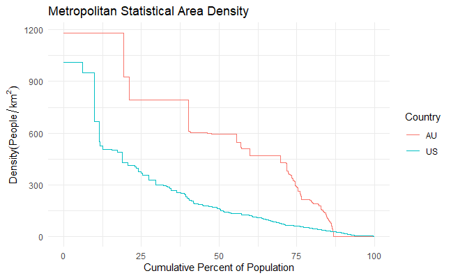

```r
PlotMSAsByDensity(msas_by_density, density = density, ccode = ccode, cum_pct = cum_pct)
```

## Source Data

### Australia

#### References:

- [Description of the Australian Statistical Geography Standard](https://www.abs.gov.au/statistics/standards/australian-statistical-geography-standard-asgs-edition-3/jul2021-jun2026#asgs-diagram)
- [ABS population data by SA2](https://www.abs.gov.au/statistics/people/population/regional-population/2020-21#data-download)
- [Significant Urban Area to SA2](https://www.abs.gov.au/AUSSTATS/abs@.nsf/DetailsPage/1270.0.55.004July%202016?OpenDocument)